# HEALTH AND LIFESTYLE FACTORS INFLUENCING INSURANCE CLAIM AMOUNT

## 📝 **INTRODUCTION**

Health insurance plays a crucial role in providing financial protection against unexpected medical expenses. Insurance companies aim to understand which factors influence the amount of claims made by policyholders so they can assess risk, design fair premium rates, and promote healthier lifestyles among customers.

In this project, we analyze a health insurance dataset to explore how demographic, health, and lifestyle factors affect insurance claim amounts. The dataset includes details such as age, gender, BMI, smoking status, diabetes, hereditary diseases, and exercise habits for each policyholder.

Through this analysis, we perform Exploratory Data Analysis (EDA) to identify patterns and relationships between these factors and claim costs. By examining distributions, relationships, and correlations, we aim to uncover key insights such as:

```
* How age and BMI impact claim amounts

* Whether smokers and diabetic individuals tend to file higher claims

* Which health or lifestyle factors contribute most to insurance costs
```

The findings from this project can help insurers in :-

```
* Risk assessment – understanding which groups are high-risk

* Premium pricing – adjusting policies fairly based on health indicators

* Policy design – promoting health awareness and preventive care
```

## 💡 **OBJECTIVES :-**

```
1. To understand the dataset structure by exploring its features, data types, and summary statistics.

2. To clean and prepare the data by handling missing values, correcting data types, and creating meaningful
   new variables such as Age Group and BMI Category.

3. To perform Exploratory Data Analysis (EDA) to study the distribution of variables and identify key patterns in the data.

4. To examine relationships between demographic (Age, Gender), lifestyle (Smoking, Exercise), and health factors
   (BMI, Diabetes, Hereditary diseases) with claim amounts.

5. To identify significant factors that contribute to higher insurance claims using visual and statistical analysis.

6. To provide actionable insights and recommendations for insurance companies to improve risk assessment and policy pricing
   strategies.
```

## 🎯 **AIM OF THE PROJECT**

The aim of this project is to analyze how demographic, health, and lifestyle factors influence insurance claim amounts. By exploring variables such as age, gender, BMI, smoking status, hereditary diseases, diabetes, and exercise habits, the project seeks to uncover key patterns and relationships that affect claim costs.  
The insights derived can help insurers in risk assessment, premium pricing, and policy design.

## 📚 **IMPORTING THE LIBRARIES**

```python
import pandas as pd
import numpy as np
import matplotlib.pyplot as plt
import seaborn as sns
import warnings
warnings.filterwarnings('ignore')
```

## 📂 **LOADING THE DATASET**

```python
df = pd.read_csv(r"D:\final project\1651277648862_healthinsurance.csv")
df
```

|  | age | sex | weight | bmi | hereditary_diseases | no_of_dependents | smoker | city | bloodpressure | diabetes | regular_ex | job_title | claim |
| --- | --- | --- | --- | --- | --- | --- | --- | --- | --- | --- | --- | --- | --- |
| 0 | 60.0 | male | 64 | 24.3 | NoDisease | 1 | 0 | NewYork | 72 | 0 | 0 | Actor | 13112.6 |
| 1 | 49.0 | female | 75 | 22.6 | NoDisease | 1 | 0 | Boston | 78 | 1 | 1 | Engineer | 9567.0 |
| 2 | 32.0 | female | 64 | 17.8 | Epilepsy | 2 | 1 | Phildelphia | 88 | 1 | 1 | Academician | 32734.2 |
| 3 | 61.0 | female | 53 | 36.4 | NoDisease | 1 | 1 | Pittsburg | 72 | 1 | 0 | Chef | 48517.6 |
| 4 | 19.0 | female | 50 | 20.6 | NoDisease | 0 | 0 | Buffalo | 82 | 1 | 0 | HomeMakers | 1731.7 |
| ... | ... | ... | ... | ... | ... | ... | ... | ... | ... | ... | ... | ... | ... |
| 14995 | 39.0 | male | 49 | 28.3 | NoDisease | 1 | 1 | Florence | 54 | 1 | 0 | FilmMaker | 21082.2 |
| 14996 | 39.0 | male | 74 | 29.6 | NoDisease | 4 | 0 | Miami | 64 | 1 | 0 | Student | 7512.3 |
| 14997 | 20.0 | male | 62 | 33.3 | NoDisease | 0 | 0 | Tampa | 52 | 1 | 0 | FashionDesigner | 1391.5 |
| 14998 | 52.0 | male | 88 | 36.7 | NoDisease | 0 | 0 | PanamaCity | 70 | 1 | 0 | Farmer | 9144.6 |
| 14999 | 52.0 | male | 57 | 26.4 | NoDisease | 3 | 0 | Kingsport | 72 | 1 | 0 | Manager | 25992.8 |

15000 rows × 13 columns

## 🔍 **DATA EXPLORATION / OVERVIEW**

```python
# Print the first few rows of the dataset to get an overview of the data

df.head()
```

|  | age | sex | weight | bmi | hereditary_diseases | no_of_dependents | smoker | city | bloodpressure | diabetes | regular_ex | job_title | claim |
| --- | --- | --- | --- | --- | --- | --- | --- | --- | --- | --- | --- | --- | --- |
| 0 | 60.0 | male | 64 | 24.3 | NoDisease | 1 | 0 | NewYork | 72 | 0 | 0 | Actor | 13112.6 |
| 1 | 49.0 | female | 75 | 22.6 | NoDisease | 1 | 0 | Boston | 78 | 1 | 1 | Engineer | 9567.0 |
| 2 | 32.0 | female | 64 | 17.8 | Epilepsy | 2 | 1 | Phildelphia | 88 | 1 | 1 | Academician | 32734.2 |
| 3 | 61.0 | female | 53 | 36.4 | NoDisease | 1 | 1 | Pittsburg | 72 | 1 | 0 | Chef | 48517.6 |
| 4 | 19.0 | female | 50 | 20.6 | NoDisease | 0 | 0 | Buffalo | 82 | 1 | 0 | HomeMakers | 1731.7 |

```python
# Obtain the number of rows and columns in the dataset

print("rows,columns",df.shape)
```

```
rows,columns (15000, 13)
```

```python
# Get a concise summary of the dataset, including the data types and non-null values

print(df.info())
```

```
<class 'pandas.core.frame.DataFrame'>
RangeIndex: 15000 entries, 0 to 14999
Data columns (total 13 columns):
 #   Column               Non-Null Count  Dtype
---  ------               --------------  -----
 0   age                  14604 non-null  float64
 1   sex                  15000 non-null  object
 2   weight               15000 non-null  int64
 3   bmi                  14044 non-null  float64
 4   hereditary_diseases  15000 non-null  object
 5   no_of_dependents     15000 non-null  int64
 6   smoker               15000 non-null  int64
 7   city                 15000 non-null  object
 8   bloodpressure        15000 non-null  int64
 9   diabetes             15000 non-null  int64
 10  regular_ex           15000 non-null  int64
 11  job_title            15000 non-null  object
 12  claim                15000 non-null  float64
dtypes: float64(3), int64(6), object(4)
memory usage: 1.5+ MB
None
```

```python
# Generate descriptive statistics for numerical columns

print(df.describe())
```

```
                age        weight           bmi  no_of_dependents  \
count  14604.000000  15000.000000  14044.000000      15000.000000
mean      39.547521     64.909600     30.266413          1.129733
std       14.015966     13.701935      6.122950          1.228469
min       18.000000     34.000000     16.000000          0.000000
25%       27.000000     54.000000     25.700000          0.000000
50%       40.000000     63.000000     29.400000          1.000000
75%       52.000000     76.000000     34.400000          2.000000
max       64.000000     95.000000     53.100000          5.000000

             smoker  bloodpressure      diabetes    regular_ex         claim
count  15000.000000   15000.000000  15000.000000  15000.000000  15000.000000
mean       0.198133      68.650133      0.777000      0.224133  13401.437620
std        0.398606      19.418515      0.416272      0.417024  12148.239619
min        0.000000       0.000000      0.000000      0.000000   1121.900000
25%        0.000000      64.000000      1.000000      0.000000   4846.900000
50%        0.000000      71.000000      1.000000      0.000000   9545.650000
75%        0.000000      80.000000      1.000000      0.000000  16519.125000
max        1.000000     122.000000      1.000000      1.000000  63770.400000
```

```python
print(df.isnull().sum())
```

```
age                    396
sex                      0
weight                   0
bmi                    956
hereditary_diseases      0
no_of_dependents         0
smoker                   0
city                     0
bloodpressure            0
diabetes                 0
regular_ex               0
job_title                0
claim                    0
dtype: int64
```

### 🚫 **HANDLING NULL VALUES**

```python
# Step 1: Handle missing 'age' first (required for AgeGroup creation)
df['age'].fillna(df['age'].median(), inplace=True)

# Step 2: Create AgeGroup bins
df['AgeGroup'] = pd.cut(df['age'],
                        bins=[18, 30, 45, 60, 80],
                        labels=['18-30', '31-45', '46-60', '61-80'])

# Step 3: Check how many BMI values are missing before imputation
print("Missing BMI values before:", df['bmi'].isnull().sum())

# Step 4: Group-wise median imputation (by sex + AgeGroup)
df['bmi'] = df.groupby(['sex', 'AgeGroup'], observed=True)['bmi'].transform(lambda x: x.fillna(x.median()))

# Step 5: Fill any remaining missing BMI values with overall median
df['bmi'].fillna(df['bmi'].median(), inplace=True)

# Step 6: Check again after imputation
print("Missing BMI values after:", df['bmi'].isnull().sum())
```

```
Missing BMI values before: 956
Missing BMI values after: 0
```

```python
print(df.isnull().sum())
```

```
age                      0
sex                      0
weight                   0
bmi                      0
hereditary_diseases      0
no_of_dependents         0
smoker                   0
city                     0
bloodpressure            0
diabetes                 0
regular_ex               0
job_title                0
claim                    0
AgeGroup               768
dtype: int64
```

```python
df.head()
```

|  | age | sex | weight | bmi | hereditary_diseases | no_of_dependents | smoker | city | bloodpressure | diabetes | regular_ex | job_title | claim | AgeGroup |
| --- | --- | --- | --- | --- | --- | --- | --- | --- | --- | --- | --- | --- | --- | --- |
| 0 | 60.0 | male | 64 | 24.3 | NoDisease | 1 | 0 | NewYork | 72 | 0 | 0 | Actor | 13112.6 | 46-60 |
| 1 | 49.0 | female | 75 | 22.6 | NoDisease | 1 | 0 | Boston | 78 | 1 | 1 | Engineer | 9567.0 | 46-60 |
| 2 | 32.0 | female | 64 | 17.8 | Epilepsy | 2 | 1 | Phildelphia | 88 | 1 | 1 | Academician | 32734.2 | 31-45 |
| 3 | 61.0 | female | 53 | 36.4 | NoDisease | 1 | 1 | Pittsburg | 72 | 1 | 0 | Chef | 48517.6 | 61-80 |
| 4 | 19.0 | female | 50 | 20.6 | NoDisease | 0 | 0 | Buffalo | 82 | 1 | 0 | HomeMakers | 1731.7 | 18-30 |

### ➕ **ADDING A NEW COLUMN**

```python
# Adding new column -BMI categories
def bmi_category(bmi):
    if bmi < 18.5:
        return 'Underweight'
    elif bmi < 25:
        return 'Normal'
    elif bmi < 30:
        return 'Overweight'
    else:
        return 'Obese'

df['BMI_Category'] = df['bmi'].apply(bmi_category)
```

```python
df.head()
```

|  | age | sex | weight | bmi | hereditary_diseases | no_of_dependents | smoker | city | bloodpressure | diabetes | regular_ex | job_title | claim | AgeGroup | BMI_Category |
| --- | --- | --- | --- | --- | --- | --- | --- | --- | --- | --- | --- | --- | --- | --- | --- |
| 0 | 60.0 | male | 64 | 24.3 | NoDisease | 1 | 0 | NewYork | 72 | 0 | 0 | Actor | 13112.6 | 46-60 | Normal |
| 1 | 49.0 | female | 75 | 22.6 | NoDisease | 1 | 0 | Boston | 78 | 1 | 1 | Engineer | 9567.0 | 46-60 | Normal |
| 2 | 32.0 | female | 64 | 17.8 | Epilepsy | 2 | 1 | Phildelphia | 88 | 1 | 1 | Academician | 32734.2 | 31-45 | Underweight |
| 3 | 61.0 | female | 53 | 36.4 | NoDisease | 1 | 1 | Pittsburg | 72 | 1 | 0 | Chef | 48517.6 | 61-80 | Obese |
| 4 | 19.0 | female | 50 | 20.6 | NoDisease | 0 | 0 | Buffalo | 82 | 1 | 0 | HomeMakers | 1731.7 | 18-30 | Normal |

```python
print(df.columns)
```

```
Index(['age', 'sex', 'weight', 'bmi', 'hereditary_diseases',
       'no_of_dependents', 'smoker', 'city', 'bloodpressure', 'diabetes',
       'regular_ex', 'job_title', 'claim', 'AgeGroup', 'BMI_Category'],
      dtype='object')
```

### 🔄 **CHANGING DATA TYPES**

```python
print(df.info())
```

```
<class 'pandas.core.frame.DataFrame'>
RangeIndex: 15000 entries, 0 to 14999
Data columns (total 15 columns):
 #   Column               Non-Null Count  Dtype
---  ------               --------------  -----
 0   age                  15000 non-null  float64
 1   sex                  15000 non-null  object
 2   weight               15000 non-null  int64
 3   bmi                  15000 non-null  float64
 4   hereditary_diseases  15000 non-null  object
 5   no_of_dependents     15000 non-null  int64
 6   smoker               15000 non-null  int64
 7   city                 15000 non-null  object
 8   bloodpressure        15000 non-null  int64
 9   diabetes             15000 non-null  int64
 10  regular_ex           15000 non-null  int64
 11  job_title            15000 non-null  object
 12  claim                15000 non-null  float64
 13  AgeGroup             14232 non-null  category
 14  BMI_Category         15000 non-null  object
dtypes: category(1), float64(3), int64(6), object(5)
memory usage: 1.6+ MB
None
```

```python
df['sex'] = df['sex'].astype('category')
df['smoker'] = df['smoker'].astype('category')
df['city'] = df['city'].astype('category')
df['diabetes'] = df['diabetes'].astype('category')
df['hereditary_diseases'] = df['hereditary_diseases'].astype('category')
df['job_title'] = df['job_title'].astype('category')
df['BMI_Category'] = df['BMI_Category'].astype('category')
```

```python
print(df.info())
```

```
<class 'pandas.core.frame.DataFrame'>
RangeIndex: 15000 entries, 0 to 14999
Data columns (total 15 columns):
 #   Column               Non-Null Count  Dtype
---  ------               --------------  -----
 0   age                  15000 non-null  float64
 1   sex                  15000 non-null  category
 2   weight               15000 non-null  int64
 3   bmi                  15000 non-null  float64
 4   hereditary_diseases  15000 non-null  category
 5   no_of_dependents     15000 non-null  int64
 6   smoker               15000 non-null  category
 7   city                 15000 non-null  category
 8   bloodpressure        15000 non-null  int64
 9   diabetes             15000 non-null  category
 10  regular_ex           15000 non-null  int64
 11  job_title            15000 non-null  category
 12  claim                15000 non-null  float64
 13  AgeGroup             14232 non-null  category
 14  BMI_Category         15000 non-null  category
dtypes: category(8), float64(3), int64(4)
memory usage: 942.8 KB
None
```

```python
# Replace shorthand values in smoker, diabetes, regular_ex columns

df["smoker"] = df["smoker"].replace({
    0: "Non-smoker",
    1: "Smoker"
})

df["diabetes"] = df["diabetes"].replace({
    0: "No",
    1: "Yes"
})

df["regular_ex"] = df["regular_ex"].replace({
    0: "No",
    1: "Yes"
})
```

```python
df.head()
```

|  | age | sex | weight | bmi | hereditary_diseases | no_of_dependents | smoker | city | bloodpressure | diabetes | regular_ex | job_title | claim | AgeGroup | BMI_Category |
| --- | --- | --- | --- | --- | --- | --- | --- | --- | --- | --- | --- | --- | --- | --- | --- |
| 0 | 60.0 | male | 64 | 24.3 | NoDisease | 1 | Non-smoker | NewYork | 72 | No | No | Actor | 13112.6 | 46-60 | Normal |
| 1 | 49.0 | female | 75 | 22.6 | NoDisease | 1 | Non-smoker | Boston | 78 | Yes | Yes | Engineer | 9567.0 | 46-60 | Normal |
| 2 | 32.0 | female | 64 | 17.8 | Epilepsy | 2 | Smoker | Phildelphia | 88 | Yes | Yes | Academician | 32734.2 | 31-45 | Underweight |
| 3 | 61.0 | female | 53 | 36.4 | NoDisease | 1 | Smoker | Pittsburg | 72 | Yes | No | Chef | 48517.6 | 61-80 | Obese |
| 4 | 19.0 | female | 50 | 20.6 | NoDisease | 0 | Non-smoker | Buffalo | 82 | Yes | No | HomeMakers | 1731.7 | 18-30 | Normal |

### 🔍 **FILTERING THE DATA**

```python
# 1. Filter rows where health_condition contains "diabetes"
# **********************************************************

diabetes_patients = df[df['diabetes'].str.contains('Yes', case=False, na=False)]
diabetes_patients
```

|  | age | sex | weight | bmi | hereditary_diseases | no_of_dependents | smoker | city | bloodpressure | diabetes | regular_ex | job_title | claim | AgeGroup | BMI_Category |
| --- | --- | --- | --- | --- | --- | --- | --- | --- | --- | --- | --- | --- | --- | --- | --- |
| 1 | 49.0 | female | 75 | 22.6 | NoDisease | 1 | Non-smoker | Boston | 78 | Yes | Yes | Engineer | 9567.0 | 46-60 | Normal |
| 2 | 32.0 | female | 64 | 17.8 | Epilepsy | 2 | Smoker | Phildelphia | 88 | Yes | Yes | Academician | 32734.2 | 31-45 | Underweight |
| 3 | 61.0 | female | 53 | 36.4 | NoDisease | 1 | Smoker | Pittsburg | 72 | Yes | No | Chef | 48517.6 | 61-80 | Obese |
| 4 | 19.0 | female | 50 | 20.6 | NoDisease | 0 | Non-smoker | Buffalo | 82 | Yes | No | HomeMakers | 1731.7 | 18-30 | Normal |
| 7 | 21.0 | male | 52 | 26.8 | NoDisease | 0 | Non-smoker | Cambridge | 74 | Yes | No | Actor | 1534.3 | 18-30 | Overweight |
| ... | ... | ... | ... | ... | ... | ... | ... | ... | ... | ... | ... | ... | ... | ... | ... |
| 14995 | 39.0 | male | 49 | 28.3 | NoDisease | 1 | Smoker | Florence | 54 | Yes | No | FilmMaker | 21082.2 | 31-45 | Overweight |
| 14996 | 39.0 | male | 74 | 29.6 | NoDisease | 4 | Non-smoker | Miami | 64 | Yes | No | Student | 7512.3 | 31-45 | Overweight |
| 14997 | 20.0 | male | 62 | 33.3 | NoDisease | 0 | Non-smoker | Tampa | 52 | Yes | No | FashionDesigner | 1391.5 | 18-30 | Obese |
| 14998 | 52.0 | male | 88 | 36.7 | NoDisease | 0 | Non-smoker | PanamaCity | 70 | Yes | No | Farmer | 9144.6 | 46-60 | Obese |
| 14999 | 52.0 | male | 57 | 26.4 | NoDisease | 3 | Non-smoker | Kingsport | 72 | Yes | No | Manager | 25992.8 | 46-60 | Overweight |

11655 rows × 15 columns

**Interpretation**:

This filter extracts all patients who have diabetes from the dataset. By focusing on diabetic patients, we can study how having this chronic condition affects insurance claim amounts. For instance, we can later compare their average claim, BMI, or blood pressure with those of non-diabetic individuals.

👉 This helps identify whether diabetes leads to higher claim costs due to frequent medical needs.

```python
# 2.Filter rows where smoking_status contains "smoker"


smokers = df[df['smoker'].str.lower()=='smoker']
smokers
```

|  | age | sex | weight | bmi | hereditary_diseases | no_of_dependents | smoker | city | bloodpressure | diabetes | regular_ex | job_title | claim | AgeGroup | BMI_Category |
| --- | --- | --- | --- | --- | --- | --- | --- | --- | --- | --- | --- | --- | --- | --- | --- |
| 2 | 32.0 | female | 64 | 17.8 | Epilepsy | 2 | Smoker | Phildelphia | 88 | Yes | Yes | Academician | 32734.2 | 31-45 | Underweight |
| 3 | 61.0 | female | 53 | 36.4 | NoDisease | 1 | Smoker | Pittsburg | 72 | Yes | No | Chef | 48517.6 | 61-80 | Obese |
| 10 | 51.0 | female | 50 | 33.0 | EyeDisease | 0 | Smoker | Syracuse | 0 | Yes | No | Police | 44400.4 | 46-60 | Obese |
| 24 | 21.0 | male | 45 | 25.7 | NoDisease | 4 | Smoker | Charlotte | 0 | Yes | No | Actor | 17942.1 | 18-30 | Overweight |
| 27 | 38.0 | male | 82 | 38.4 | Alzheimer | 3 | Smoker | Nashville | 86 | Yes | No | Dancer | 41949.2 | 31-45 | Obese |
| ... | ... | ... | ... | ... | ... | ... | ... | ... | ... | ... | ... | ... | ... | ... | ... |
| 14976 | 19.0 | male | 47 | 29.0 | NoDisease | 0 | Smoker | Portland | 69 | No | No | Actor | 20327.3 | 18-30 | Overweight |
| 14977 | 45.0 | female | 84 | 28.9 | NoDisease | 1 | Smoker | Cambridge | 0 | Yes | Yes | ITProfessional | 39725.5 | 31-45 | Overweight |
| 14983 | 37.0 | female | 76 | 38.4 | HeartDisease | 0 | Smoker | Louisville | 86 | Yes | No | ITProfessional | 40419.0 | 31-45 | Obese |
| 14990 | 43.0 | male | 72 | 36.0 | NoDisease | 3 | Smoker | Oklahoma | 74 | Yes | No | Manager | 42124.5 | 31-45 | Obese |
| 14995 | 39.0 | male | 49 | 28.3 | NoDisease | 1 | Smoker | Florence | 54 | Yes | No | FilmMaker | 21082.2 | 31-45 | Overweight |

2972 rows × 15 columns

**Interpretation**:

This filter selects only the individuals who are smokers. By isolating smokers, we can analyze whether smoking habits have a significant influence on health-related claim amounts. For example, smokers are more likely to have higher medical costs because of increased risk of heart and lung diseases.

👉 This filter allows a focused study on lifestyle factors affecting insurance claims.

```python
# 3.combine 2 conditions : Patients  who have "diabetes" AND are "smokers"


filtered_rows = diabetes_patients = df[
    (df['diabetes'].str.contains('Yes', case=False, na=False)) &
    (df['smoker'].str.lower()=='smoker')]

filtered_rows
```

|  | age | sex | weight | bmi | hereditary_diseases | no_of_dependents | smoker | city | bloodpressure | diabetes | regular_ex | job_title | claim | AgeGroup | BMI_Category |
| --- | --- | --- | --- | --- | --- | --- | --- | --- | --- | --- | --- | --- | --- | --- | --- |
| 2 | 32.0 | female | 64 | 17.8 | Epilepsy | 2 | Smoker | Phildelphia | 88 | Yes | Yes | Academician | 32734.2 | 31-45 | Underweight |
| 3 | 61.0 | female | 53 | 36.4 | NoDisease | 1 | Smoker | Pittsburg | 72 | Yes | No | Chef | 48517.6 | 61-80 | Obese |
| 10 | 51.0 | female | 50 | 33.0 | EyeDisease | 0 | Smoker | Syracuse | 0 | Yes | No | Police | 44400.4 | 46-60 | Obese |
| 24 | 21.0 | male | 45 | 25.7 | NoDisease | 4 | Smoker | Charlotte | 0 | Yes | No | Actor | 17942.1 | 18-30 | Overweight |
| 27 | 38.0 | male | 82 | 38.4 | Alzheimer | 3 | Smoker | Nashville | 86 | Yes | No | Dancer | 41949.2 | 31-45 | Obese |
| ... | ... | ... | ... | ... | ... | ... | ... | ... | ... | ... | ... | ... | ... | ... | ... |
| 14971 | 18.0 | female | 53 | 29.5 | NoDisease | 3 | Smoker | Boston | 85 | Yes | No | Student | 18223.5 | NaN | Overweight |
| 14977 | 45.0 | female | 84 | 28.9 | NoDisease | 1 | Smoker | Cambridge | 0 | Yes | Yes | ITProfessional | 39725.5 | 31-45 | Overweight |
| 14983 | 37.0 | female | 76 | 38.4 | HeartDisease | 0 | Smoker | Louisville | 86 | Yes | No | ITProfessional | 40419.0 | 31-45 | Obese |
| 14990 | 43.0 | male | 72 | 36.0 | NoDisease | 3 | Smoker | Oklahoma | 74 | Yes | No | Manager | 42124.5 | 31-45 | Obese |
| 14995 | 39.0 | male | 49 | 28.3 | NoDisease | 1 | Smoker | Florence | 54 | Yes | No | FilmMaker | 21082.2 | 31-45 | Overweight |

2454 rows × 15 columns

**Interpretation**:

This filter narrows down the dataset to include only those patients who both smoke and have diabetes. Such individuals are at higher health risk, as both smoking and diabetes contribute to chronic diseases. Analyzing this group helps in understanding how multiple health and lifestyle factors together impact insurance claim amounts.

👉 It provides insights useful for risk assessment and premium pricing in insurance.

```python
# 4.combine 2 conditions : Filter rows where person is either obese OR has diabetes

filtered_rows = df[
    (df['BMI_Category'] == 'Obese') |
    (df['diabetes'].str.contains('Yes', case=False, na=False))]

filtered_rows
```

|  | age | sex | weight | bmi | hereditary_diseases | no_of_dependents | smoker | city | bloodpressure | diabetes | regular_ex | job_title | claim | AgeGroup | BMI_Category |
| --- | --- | --- | --- | --- | --- | --- | --- | --- | --- | --- | --- | --- | --- | --- | --- |
| 1 | 49.0 | female | 75 | 22.6 | NoDisease | 1 | Non-smoker | Boston | 78 | Yes | Yes | Engineer | 9567.0 | 46-60 | Normal |
| 2 | 32.0 | female | 64 | 17.8 | Epilepsy | 2 | Smoker | Phildelphia | 88 | Yes | Yes | Academician | 32734.2 | 31-45 | Underweight |
| 3 | 61.0 | female | 53 | 36.4 | NoDisease | 1 | Smoker | Pittsburg | 72 | Yes | No | Chef | 48517.6 | 61-80 | Obese |
| 4 | 19.0 | female | 50 | 20.6 | NoDisease | 0 | Non-smoker | Buffalo | 82 | Yes | No | HomeMakers | 1731.7 | 18-30 | Normal |
| 5 | 42.0 | female | 89 | 37.9 | NoDisease | 0 | Non-smoker | AtlanticCity | 78 | No | No | Dancer | 6474.0 | 31-45 | Obese |
| ... | ... | ... | ... | ... | ... | ... | ... | ... | ... | ... | ... | ... | ... | ... | ... |
| 14995 | 39.0 | male | 49 | 28.3 | NoDisease | 1 | Smoker | Florence | 54 | Yes | No | FilmMaker | 21082.2 | 31-45 | Overweight |
| 14996 | 39.0 | male | 74 | 29.6 | NoDisease | 4 | Non-smoker | Miami | 64 | Yes | No | Student | 7512.3 | 31-45 | Overweight |
| 14997 | 20.0 | male | 62 | 33.3 | NoDisease | 0 | Non-smoker | Tampa | 52 | Yes | No | FashionDesigner | 1391.5 | 18-30 | Obese |
| 14998 | 52.0 | male | 88 | 36.7 | NoDisease | 0 | Non-smoker | PanamaCity | 70 | Yes | No | Farmer | 9144.6 | 46-60 | Obese |
| 14999 | 52.0 | male | 57 | 26.4 | NoDisease | 3 | Non-smoker | Kingsport | 72 | Yes | No | Manager | 25992.8 | 46-60 | Overweight |

12834 rows × 15 columns

**Interpretation**:

👉 This helps insurers understand the individual and combined effect of health risk factors.

### 📊 **AGGREGATION**

```python
# Single Aggregation - average claim amount by Age group

df.groupby('AgeGroup')['claim'].mean()
```

```
AgeGroup
18-30     9950.731776
31-45    12560.311778
46-60    16464.324616
61-80    21535.716472
Name: claim, dtype: float64
```

**Interpretation**:

This aggregation calculates the average insurance claim amount for each age group. It helps to understand how age influences healthcare costs. If older groups (e.g., 61–80) show higher averages, it means health risks and medical expenses increase with age, leading to higher claim amounts.

```python
# Single Aggregation - average claim amount by sex

df.groupby('sex')['claim'].mean()
```

```
sex
female    12692.053515
male      14140.170223
Name: claim, dtype: float64
```

**Interpretation**:

This shows how male and female policyholders differ in their average claim amounts. It may reveal small differences depending on lifestyle or health conditions, helping insurers understand gender-based risk patterns.

```python
# Multiple Aggregations - average, min, and max claim amount by smoking status

df.groupby('smoker')['claim'].agg(['mean', 'min', 'max'])
```

| smoker | mean | min | max |
| --- | --- | --- | --- |
| Non-smoker | 8731.296799 | 1121.9 | 40114.8 |
| Smoker | 32301.994078 | 3480.8 | 63770.4 |

**Interpretation**:

Smokers have higher average and maximum claim amounts than non-smokers, showing that smoking increases health risks and medical costs.

```python
# Aggregation by Multiple Columns - average claim by gender and smoking status

df.groupby(['sex', 'smoker'])['claim'].mean()
```

```
sex     smoker
female  Non-smoker     8968.232594
        Smoker        30971.844710
male    Non-smoker     8465.699753
        Smoker        33329.151759
Name: claim, dtype: float64
```

**Interpretation**:

This shows the average claim amount for each combination of gender and smoking status. Smokers of both genders have higher average claims than non-smokers, indicating that smoking increases medical expenses regardless of gender.

```python
# Count of Records in Each Group - count how many people are in each BMI category

df['BMI_Category'].value_counts()
```

```
BMI_Category
Obese          6314
Overweight     6110
Normal         2390
Underweight     186
Name: count, dtype: int64
```

**Interpretation**:

```python
# by two categories

df.groupby(['BMI_Category', 'smoker']).size()
```

```
BMI_Category  smoker
Normal        Non-smoker    1886
              Smoker         504
Obese         Non-smoker    4995
              Smoker        1319
Overweight    Non-smoker    4978
              Smoker        1132
Underweight   Non-smoker     169
              Smoker          17
dtype: int64
```

**Interpretation**:

This shows the count of individuals in each combination of BMI category and smoking status. It helps compare how many smokers and non-smokers fall into each BMI group — for example, whether most smokers are overweight or obese, which can reveal links between lifestyle habits and body weight.

```python
# Statistical Summary
df.describe()
```

|  | age | weight | bmi | no_of_dependents | bloodpressure | claim |
| --- | --- | --- | --- | --- | --- | --- |
| count | 15000.000000 | 15000.000000 | 15000.00000 | 15000.000000 | 15000.000000 | 15000.000000 |
| mean | 39.559467 | 64.909600 | 30.26272 | 1.129733 | 68.650133 | 13401.437620 |
| std | 13.829896 | 13.701935 | 5.77655 | 1.228469 | 19.418515 | 12148.239619 |
| min | 18.000000 | 34.000000 | 16.80000 | 0.000000 | 0.000000 | 1121.900000 |
| 25% | 27.000000 | 54.000000 | 26.40000 | 0.000000 | 64.000000 | 4846.900000 |
| 50% | 40.000000 | 63.000000 | 29.50000 | 1.000000 | 71.000000 | 9545.650000 |
| 75% | 51.000000 | 76.000000 | 33.80000 | 2.000000 | 80.000000 | 16519.125000 |
| max | 64.000000 | 95.000000 | 52.60000 | 5.000000 | 122.000000 | 63770.400000 |

### 📊 STATISTICAL SUMMARY

The summary shows key statistics for numeric variables such as age, BMI, and claim amount.  
We can observe the following:

- The **average claim amount** is moderate but shows a **high standard deviation**, indicating large variations.
- The **maximum claim amount** is significantly higher than the mean, confirming the presence of **outliers**.
- The **BMI** values are mostly within the normal to overweight range.

## 🔍 **EXPLORATORY DATA ANALYSIS**

```python
#  DATA OVERVIEW

# Basic info
df.info()

# Summary statistics
df.describe()

# Check shape
print("Rows:", df.shape[0], "Columns:", df.shape[1])

# Check for missing values
df.isnull().sum()

# Check unique values in each categorical column
for col in ['sex', 'smoker', 'diabetes', 'BMI_Category']:
    print(f"\nUnique values in {col}:")
    print(df[col].unique())
```

```
<class 'pandas.core.frame.DataFrame'>
RangeIndex: 15000 entries, 0 to 14999
Data columns (total 15 columns):
 #   Column               Non-Null Count  Dtype
---  ------               --------------  -----
 0   age                  15000 non-null  float64
 1   sex                  15000 non-null  category
 2   weight               15000 non-null  int64
 3   bmi                  15000 non-null  float64
 4   hereditary_diseases  15000 non-null  category
 5   no_of_dependents     15000 non-null  int64
 6   smoker               15000 non-null  category
 7   city                 15000 non-null  category
 8   bloodpressure        15000 non-null  int64
 9   diabetes             15000 non-null  category
 10  regular_ex           15000 non-null  object
 11  job_title            15000 non-null  category
 12  claim                15000 non-null  float64
 13  AgeGroup             14232 non-null  category
 14  BMI_Category         15000 non-null  category
dtypes: category(8), float64(3), int64(3), object(1)
memory usage: 942.8+ KB

Unique values in sex:
['male', 'female']
Categories (2, object): ['female', 'male']

Unique values in smoker:
['Non-smoker', 'Smoker']
Categories (2, object): ['Non-smoker', 'Smoker']

Unique values in diabetes:
['No', 'Yes']
Categories (2, object): ['No', 'Yes']

Unique values in BMI_Category:
['Normal', 'Underweight', 'Obese', 'Overweight']
Categories (4, object): ['Normal', 'Obese', 'Overweight', 'Underweight']
```

## 📈 **UNIVARIATE ANALYSIS**

### 🔹 Age - Distribution

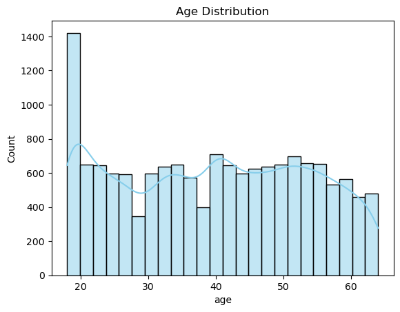

```python
sns.histplot(df['age'], kde=True, color='skyblue')
plt.title("Age Distribution")
plt.show()
```

**Interpretation**:

### 🔹 BMI - Distribution

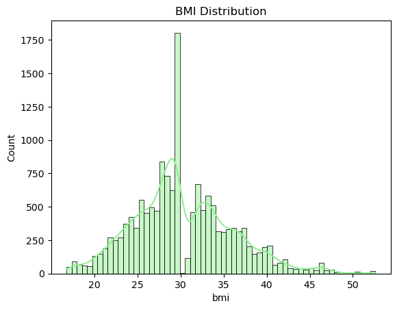

```python
sns.histplot(df['bmi'], kde=True, color='lightgreen')
plt.title("BMI Distribution")
plt.show()
```

**Interpretation**:

Most individuals have a BMI between 20–30, showing that the dataset includes mostly normal or slightly overweight people. A few people have very high BMI values, indicating potential obesity-related health risks.

### 🔹 Claim Amount - Distribution

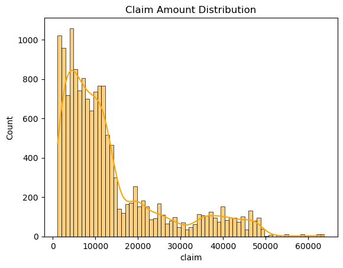

```python
sns.histplot(df['claim'], kde=True, color='orange')
plt.title("Claim Amount Distribution")
plt.show()
```

**Interpretation**:

The distribution of claim amounts is right-skewed, meaning most claims are small, and only a few policyholders have very high claims. This is typical in insurance data — large claims are rare but expensive.

### (b) Categorical Variables

### 🔹 Sex - Distribution

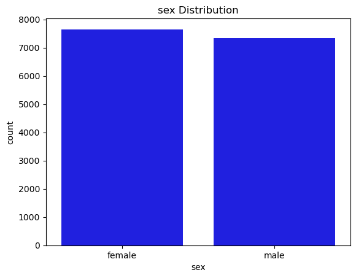

```python
sns.countplot(x='sex', data=df, color = 'blue')
plt.title("sex Distribution")
plt.show()
```

**Interpretation**:

### 🔹 Smoker - Distribution

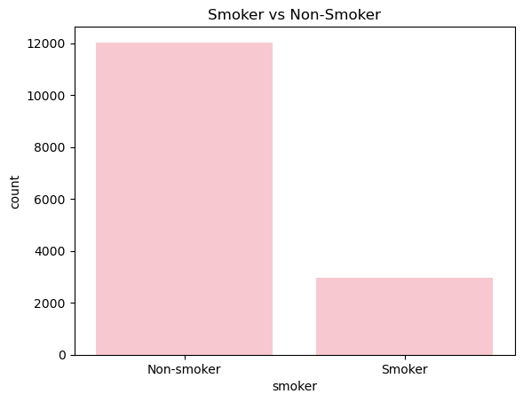

```python
sns.countplot(x='smoker', data=df,color = 'pink')
plt.title("Smoker vs Non-Smoker")
plt.show()
```

**Interpretation**:

### 🔹 Diabetes - Distribution

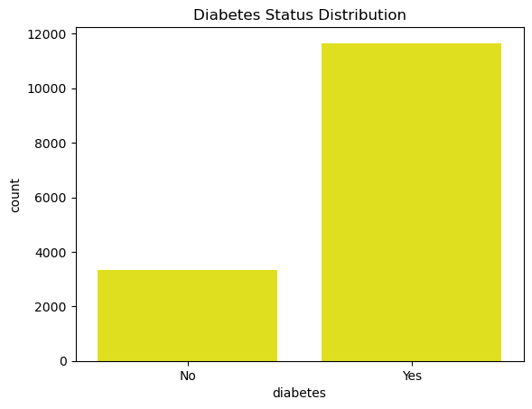

```python
sns.countplot(x='diabetes', data=df,color='yellow')
plt.title("Diabetes Status Distribution")
plt.show()
```

**Interpretation**:

The dataset shows a huge variation of counts persons with diabetes and without diabetes. There’s a large difference, it may indicate that the company has more customers from person who have diabetes,which means that persons with diabetes is more likely to have policy.

### 🔸 Pie Chart of BMI Category

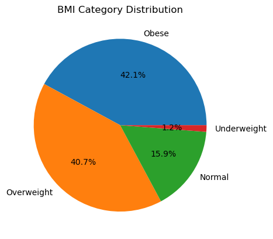

```python
bmi_counts = df['BMI_Category'].value_counts()
plt.pie(bmi_counts, labels=bmi_counts.index, autopct='%1.1f%%')
plt.title("BMI Category Distribution")
plt.show()
```

**Interpretation**:

## 📊 **BIVARIATE ANALYSIS**

### (a) Claim Amount vs Smoker

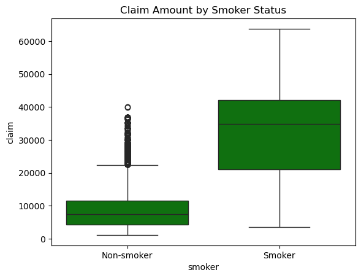

```python
sns.boxplot(x='smoker', y='claim', data=df,color='green')
plt.title("Claim Amount by Smoker Status")
plt.show()
```

**Interpretation**:

Smokers show higher median and wider range of claim amounts compared to non-smokers, confirming that smoking leads to higher health expenses.

### (b) Claim Amount by Diabetes Status

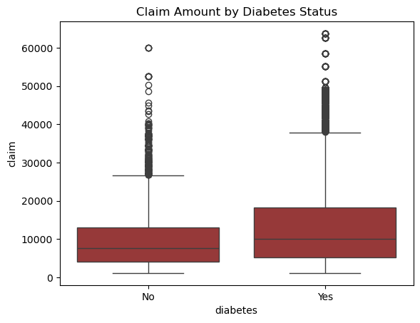

```python
sns.boxplot(x='diabetes', y='claim', data=df,color='#a52a2a')
plt.title("Claim Amount by Diabetes Status")
plt.show()
```

**Interpretation**:

Policyholders with diabetes tend to have higher claim amounts compared to non-diabetics. This suggests that diabetes is an important factor influencing medical expenses.

### (c) Claim Amount by BMI Category

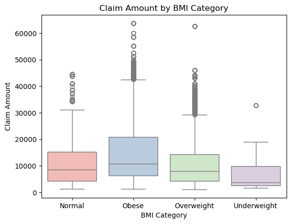

```python
sns.boxplot(x='BMI_Category', y='claim', data=df, palette='Pastel1')
plt.title("Claim Amount by BMI Category")
plt.xlabel("BMI Category")
plt.ylabel("Claim Amount")
plt.show()
```

**Interpretation**:

The Obese category has the highest median claim amount, indicating BMI has a positive relationship with health claim costs.

### (d) Claim Amount vs Gender

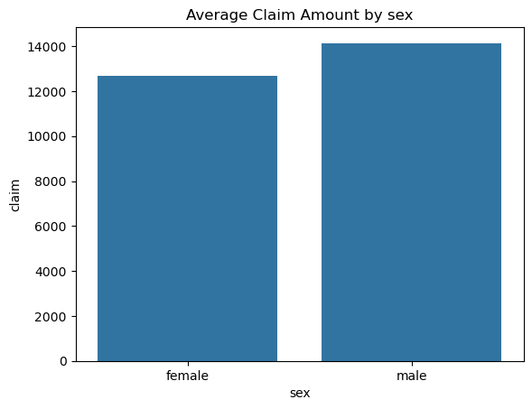

```python
sns.barplot(x='sex', y='claim', data=df, estimator='mean', ci=None)
plt.title("Average Claim Amount by sex")
plt.show()
```

**Interpretation**:

Average claim amounts are similar across genders, though slight variations may exist based on age or lifestyle factors.

### (e) Age vs Claim Amount

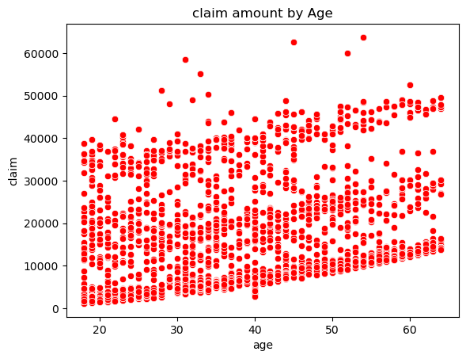

```python
sns.scatterplot(x='age', y='claim', data=df, color='red')
plt.title("claim amount by Age")
plt.show()
```

**Interpretation**:

Claim amounts increase with age, showing that older policyholders are more likely to make higher insurance claims.

## 📊 **MULTIVARIATE ANALYSIS** (3+ Variables)

### (a) Pivot table

```python
pivot_table = pd.pivot_table(df,
                             index='AgeGroup',
                             columns='smoker',
                             values='claim',
                             aggfunc='mean')
pivot_table
```

| smoker AgeGroup | Non-smoker | Smoker |
| --- | --- | --- |
| 18-30 | 4928.399695 | 27718.359281 |
| 31-45 | 7440.974081 | 31298.178025 |
| 46-60 | 12433.526097 | 37038.192057 |
| 61-80 | 15630.280195 | 40438.385268 |

**Interpretation**

This pivot table shows the average claim amount for each age group divided by smoking status.  
It clearly indicates that older smokers have the highest average claim amounts, confirming that both age and smoking together influence medical costs.

```python
pd.pivot_table(df, index='BMI_Category', columns='sex', values='claim', aggfunc='mean',observed = False)
```

| sex BMI_Category | female | male |
| --- | --- | --- |
| Normal | 11271.607646 | 11023.876894 |
| Obese | 15436.519888 | 17437.181403 |
| Overweight | 11096.842155 | 11437.962414 |
| Underweight | 7402.387963 | 5255.935897 |

**Interpretation**

```python
pd.pivot_table(df, index='smoker', values='claim', aggfunc='mean',observed=False)
```

| smoker | claim |
| --- | --- |
| Non-smoker | 8731.296799 |
| Smoker | 32301.994078 |

**Interpretation**

The pivot table shows that smokers have a higher average claim amount compared to non-smokers. This indicates that smoking is linked to increased health risks and medical expenses, leading to larger insurance claims.

```python
avg_claim_by_age = df.groupby('AgeGroup')['claim'].mean()
avg_claim_by_bmi = df.groupby('BMI_Category')['claim'].mean()
```

```python
print("Average Claim by Age Group:\n", avg_claim_by_age)
```

```
Average Claim by Age Group:
 AgeGroup
18-30     9950.731776
31-45    12560.311778
46-60    16464.324616
61-80    21535.716472
Name: claim, dtype: float64
```

**Interpretation**:

The printed output shows the average claim amount for each age group. It can be seen that older age groups have higher average claims, suggesting that health risks and medical costs increase with age.

```python
print("\nAverage Claim by BMI Category:\n", avg_claim_by_bmi)
```

```
Average Claim by BMI Category:
 BMI_Category
Normal         11162.150042
Obese          16533.810168
Overweight     11250.430016
Underweight     6502.262903
Name: claim, dtype: float64
```

**Interpretation**:

The results show the average claim amount for each BMI category. Individuals in the Overweight and Obese categories have higher average claim amounts than those in the Normal or Underweight groups, indicating that higher BMI is associated with increased health expenses and insurance claims.

### (b) Claim amount by Age Group and Smoking Status

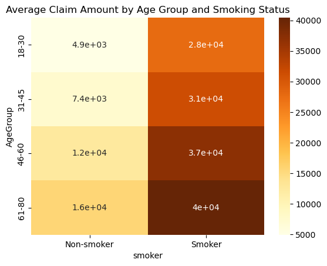

```python
table = pd.pivot_table(df, index='AgeGroup', columns='smoker', values='claim', aggfunc='mean')
sns.heatmap(table, annot=True, cmap='YlOrBr')
plt.title("Average Claim Amount by Age Group and Smoking Status")
plt.show()
```

**Interpretation**:

Older smokers have the highest average claim amounts, showing a combined effect of age and smoking on healthcare costs. Younger non-smokers have the lowest claims, highlighting lower risk in that segment.

### (c) Correlation Heatmap

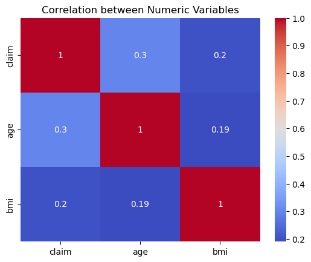

```python
corr = df[["claim","age","bmi"]].corr()
sns.heatmap(corr, annot=True, cmap="coolwarm")
plt.title("Correlation between Numeric Variables")
plt.show()
```

**Interpretation**:

## 🎨 **DATA VISUALIZATION**

### 📊 Use Matplotlib / Seaborn to generate meaningful visualizations

## **UNIVARIATE ANALYSIS**

### 1.Histogram — Age Distribution

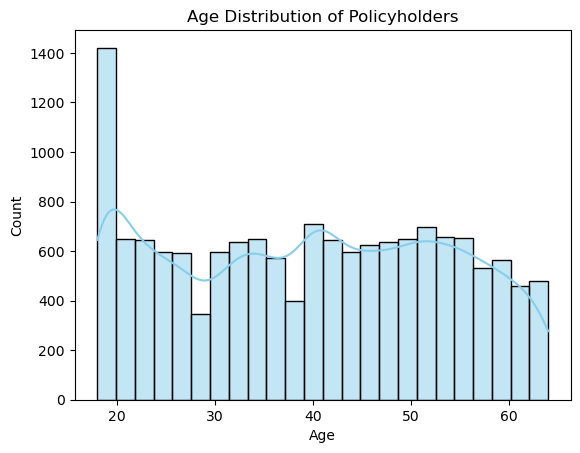

```python
sns.histplot(df['age'], kde=True, color='skyblue')
plt.title("Age Distribution of Policyholders")
plt.xlabel("Age")
plt.ylabel("Count")
plt.show()
```

**Interpretation**:

This histogram shows how ages are distributed among the insured individuals. Most policyholders fall into the middle age range, indicating that insurance claims are more common among adults aged 30–60 years.

### 2.Pie Chart — Smoking Status

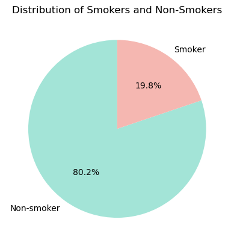

```python
smoker_counts = df['smoker'].value_counts()
plt.pie(smoker_counts, labels=smoker_counts.index, autopct='%1.1f%%', startangle=90, colors=['#a3e4d7','#f5b7b1'])
plt.title("Distribution of Smokers and Non-Smokers")
plt.show()
```

**Interpretation**:

The pie chart shows the proportion of smokers and non-smokers in the dataset. If non-smokers occupy a larger portion, it indicates a generally healthier population among the insured individuals.

### 3.Count Plot — Gender Distribution

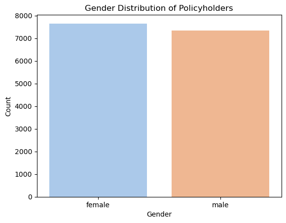

```python
sns.countplot(x='sex', data=df, palette='pastel')
plt.title("Gender Distribution of Policyholders")
plt.xlabel("Gender")
plt.ylabel("Count")
plt.show()
```

**Interpretation**:

This count plot shows how many male and female policyholders are present in the dataset. It helps identify if one gender is more represented or has more claim cases.

## **BIVARIATE ANALYSIS**

### 1. Bar Plot — Average Claim Amount by Age Group

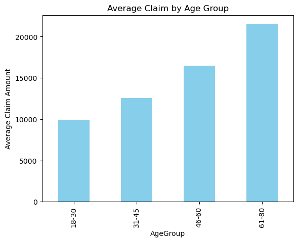

```python
avg_claim_by_age.plot(kind='bar', color='skyblue')
plt.title("Average Claim by Age Group")
plt.ylabel("Average Claim Amount")
plt.show()
```

**Interpretation**:

Average claim amounts increase with age, especially for people above 45. Older policyholders are more likely to have health issues, resulting in higher medical claims.

### 2. Bar Plot — Average Claim Amount by BMI category

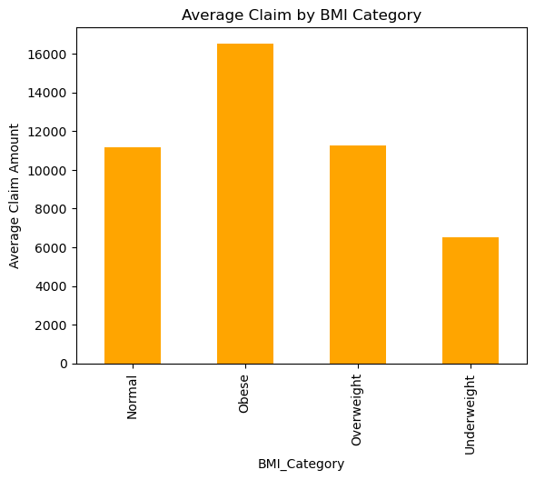

```python
avg_claim_by_bmi.plot(kind='bar', color='orange')
plt.title("Average Claim by BMI Category")
plt.ylabel("Average Claim Amount")
plt.show()
```

**Interpretation**:

The Obese category shows the highest average claim amount, followed by the Overweight group. This supports the observation that a higher BMI is linked to higher medical costs.

### 3. Scatterplot - BMI vs Claim Amount

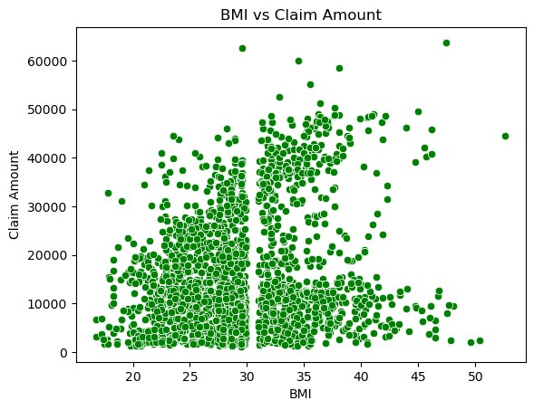

```python
sns.scatterplot(x='bmi', y='claim', data=df, color='green')
plt.title("BMI vs Claim Amount")
plt.xlabel("BMI")
plt.ylabel("Claim Amount")
plt.show()
```

**Interpretation**:

Claim amounts tend to increase with higher BMI, indicating that overweight and obese individuals incur more medical expenses.

### 4. Line Chart - Average Claim by Age

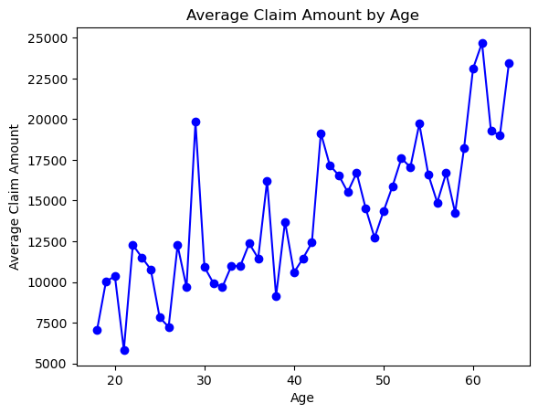

```python
age_claim = df.groupby('age')['claim'].mean().reset_index()

plt.plot(age_claim['age'], age_claim['claim'], color='blue', marker='o')
plt.title("Average Claim Amount by Age")
plt.xlabel("Age")
plt.ylabel("Average Claim Amount")
plt.show()
```

**Interpretation**:

The line chart shows a gradual increase in average claim amount as age increases. Older individuals typically have higher medical expenses.

### 5. Stacked Bar Chart - Smoking Status by Gender

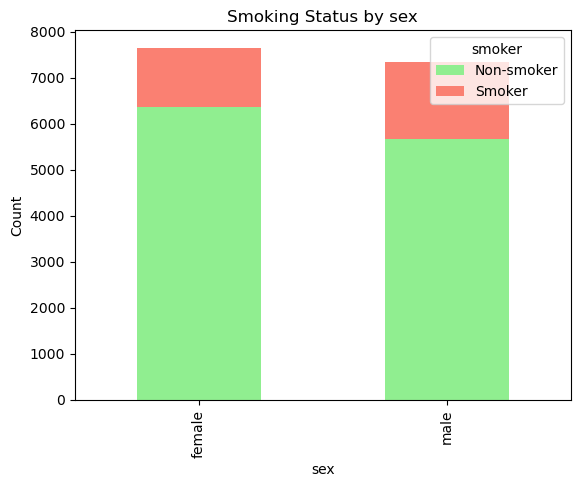

```python
pd.crosstab(df['sex'], df['smoker']).plot(kind='bar', stacked=True, color=['lightgreen', 'salmon'])
plt.title("Smoking Status by sex")
plt.xlabel("sex")
plt.ylabel("Count")
plt.show()
```

**Interpretation**:

Both genders include smokers, but the number of non-smokers is higher across both. It visually shows gender distribution among smoker categories.

### 6. Bar Plot - Average Claim by Diabetes Status

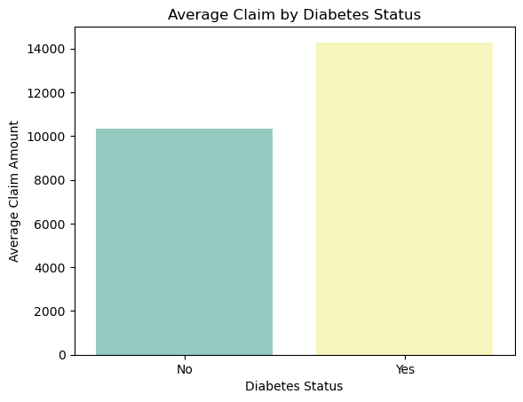

```python
sns.barplot(x='diabetes', y='claim', data=df, estimator='mean', ci=None, palette='Set3')
plt.title("Average Claim by Diabetes Status")
plt.xlabel("Diabetes Status")
plt.ylabel("Average Claim Amount")
plt.show()
```

**Interpretation**:

People with diabetes have a higher average claim amount compared to non-diabetics, suggesting a direct link between chronic illness and healthcare cost.

### 7. Violin Plot - Claim Amount by Smoking Status

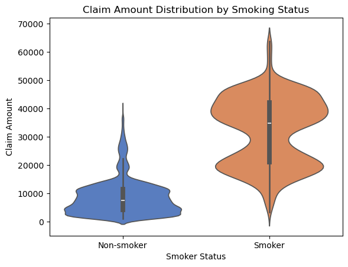

```python
sns.violinplot(x='smoker', y='claim', data=df, palette='muted')
plt.title("Claim Amount Distribution by Smoking Status")
plt.xlabel("Smoker Status")
plt.ylabel("Claim Amount")
plt.show()
```

**Interpretation**:

The violin plot shows both the spread and distribution of claim amounts for smokers and non-smokers. Smokers have a wider and higher distribution, meaning they tend to make larger and more variable claims compared to non-smokers.

### 8. Joint Plot - BMI vs Claim Amount

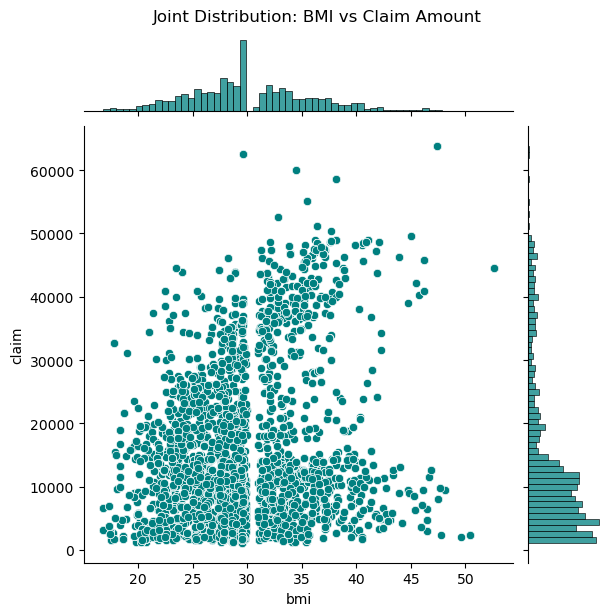

```python
sns.jointplot(x='bmi', y='claim', data=df, kind='scatter', color='teal')
plt.suptitle("Joint Distribution: BMI vs Claim Amount", y=1.02)
plt.show()
```

**Interpretation**:

The scatter joint plot shows a positive trend — as BMI increases, claim amounts also rise. It helps visualize both the density and relationship in one chart.

### 9. Boxen Plot - Claim amount vs Age group

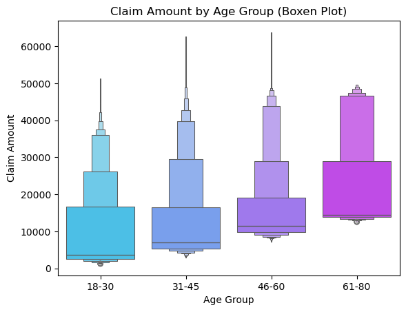

```python
sns.boxenplot(x='AgeGroup', y='claim', data=df, palette='cool')
plt.title("Claim Amount by Age Group (Boxen Plot)")
plt.xlabel("Age Group")
plt.ylabel("Claim Amount")
plt.show()
```

**Interpretation**:

### 10. Joint Plot (with regression line)

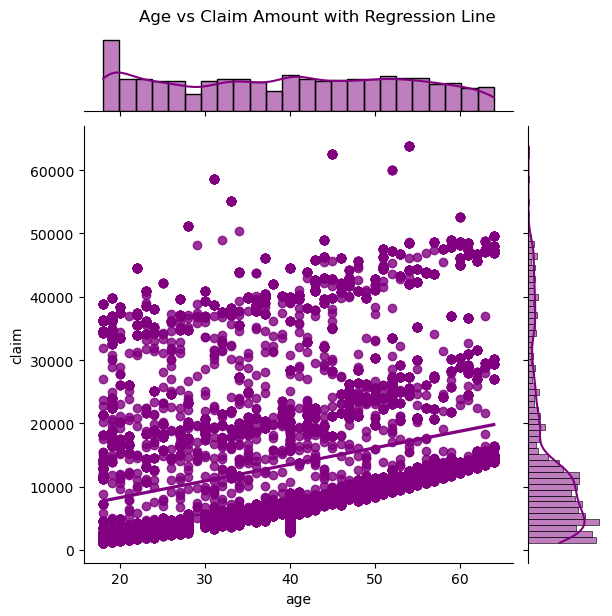

```python
sns.jointplot(x='age', y='claim', data=df, kind='reg', color='purple')
plt.suptitle("Age vs Claim Amount with Regression Line", y=1.02)
plt.show()
```

**Interpretation**:

The regression joint plot clearly shows that claim amounts increase with age, indicating an upward linear relationship between the two variables.

## **MULTIVARIATE ANALYSIS**

### 1. Box plot - Claim Amount by Smoker Status and Gender

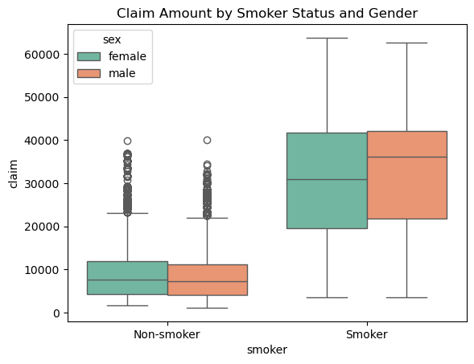

```python
sns.boxplot(x='smoker', y='claim', hue='sex', data=df, palette='Set2')
plt.title("Claim Amount by Smoker Status and Gender")
plt.show()
```

**Interpretation**:

The boxplot shows that smokers tend to have significantly higher insurance claim amounts compared to non-smokers. Among non-smokers, claim amounts are lower and mostly concentrated below 12,000, with a few outliers. Among smokers, claims are higher, with median values around 30,000–35,000, and greater variability. Gender does not appear to have a major impact on claim amounts in either group.

### 2. Pair Plot - Relationship between Multiple Variables

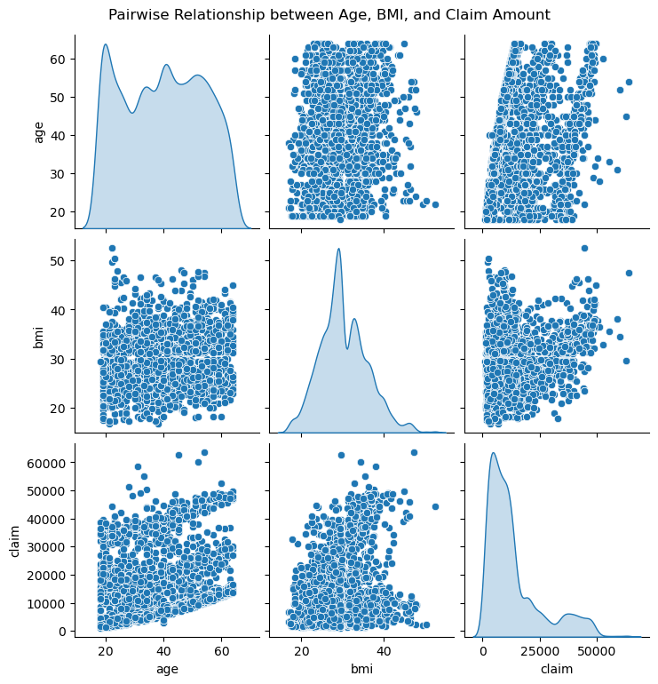

```python
sns.pairplot(df[['age', 'bmi', 'claim']], diag_kind='kde')
plt.suptitle("Pairwise Relationship between Age, BMI, and Claim Amount", y=1.02)
plt.show()
```

**Interpretation**:

This plot shows how numeric variables relate to each other. It confirms that age and BMI both positively influence claim_amount.

### 3. Correlation Between Age, BMI, and Claim

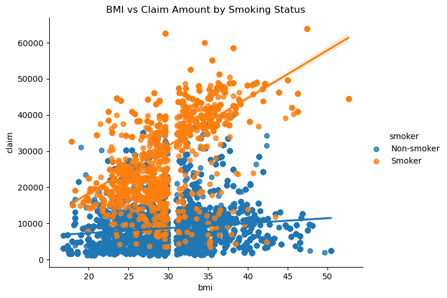

```python
sns.lmplot(x='bmi', y='claim', data=df, hue='smoker', aspect=1.3)
plt.title("BMI vs Claim Amount by Smoking Status")
plt.show()
```

**Interpretation**:

Among smokers, claim amounts rise more sharply with BMI compared to non-smokers. This highlights how smoking amplifies the effect of high BMI on health risk.

### 4. Box Plot with Hue — Claim by BMI Category and Gender

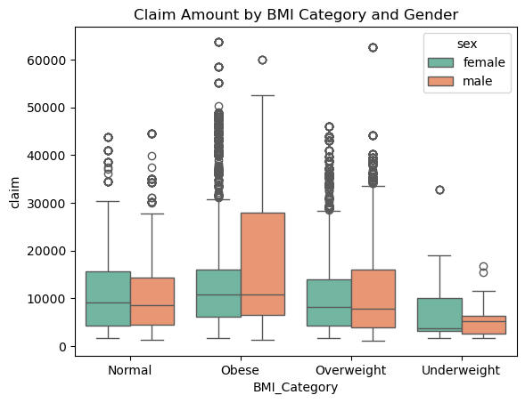

```python
sns.boxplot(x='BMI_Category', y='claim', hue='sex', data=df, palette='Set2')
plt.title("Claim Amount by BMI Category and Gender")
plt.show()
```

**Interpretation**:

This multivariate box plot shows how claim amounts vary across BMI categories for both males and females. It highlights how gender and BMI together influence medical expenses — obese males or females may have higher claim costs.

# **PROJECT SUMMARY — HEALTH INSURANCE CLAIM ANALYSIS**

## 🎯Project Aim

The aim of this project is to analyze how demographic, health, and lifestyle factors influence insurance claim amounts. By exploring variables such as age, gender, BMI, smoking status, hereditary diseases, diabetes, and exercise habits, this project seeks to uncover key patterns and relationships that affect claim costs. The insights derived can help insurers improve risk assessment, premium pricing, and policy design.

## 🎯 Scope of the Study

This study focuses on analyzing how demographic, health, and lifestyle factors influence the insurance claim amount of individuals. By examining variables such as age, gender, BMI, smoking status, hereditary diseases, diabetes, and exercise habits, the project explores patterns that affect medical costs and claim behavior.

The scope includes:

- Understanding how individual characteristics like age and BMI impact healthcare expenses.
- Identifying how lifestyle choices such as smoking and exercise influence claim amounts.
- Comparing different health conditions (like diabetes or hereditary diseases) to see their effect on insurance costs.
- Discovering correlations and trends between multiple factors to support better risk assessment and premium pricing.

## 📂 Dataset Overview

Dataset Name: Health Insurance Data

No. of Records: 15000

**Features Included:**

Health: bmi, diabetes, hereditary_diseases

Lifestyle: smoker, exercise_frequency

Target: claim_amount

## ⚙️ Data Cleaning Steps

**Handled Missing Values:**

Numeric columns filled with median values.

**Created New Columns:**

BMI_Category (Underweight, Normal, Overweight, Obese)

## 🔍 Exploratory Data Analysis (EDA)

🔹 **Univariate Analysis**

Majority have normal or overweight BMI.

Claim amounts are right-skewed, meaning most people make small claims, while a few make very large ones.

Non-smokers form the majority, with fewer smokers in the dataset.

🔹**Bivariate Analysis**

Smokers have significantly higher claim amounts than non-smokers.

Obese individuals show higher average claims compared to normal-weight policyholders.

Diabetic patients have slightly higher claim costs than non-diabetics.

Claim amount increases with age, especially for policyholders above 45 years.

🔹**Multivariate Analysis**

A heatmap and pivot tables show that older smokers have the highest average claim amounts.

There’s a positive correlation between age, bmi, and claim_amount.

Combining factors (age, smoking, BMI) explains claim variability more accurately than a single factor.

## 📊 Visualizations Used

To explore the data from multiple angles, the following charts were used:

- Histogram - Show distribution of numeric data
- Bar Plot - Compare averages between groups
- Pie Chart - Show proportions of categories
- Box Plot - Display spread and outliers
- Scatter Plot - Show relationship between two numeric variables
- Heatmap - Display correlations or group averages
- Violin - Show detailed data distributions
- Line Chart - Show trends (e.g., claim vs. age)
- Pair Plot - Visualize relationships between multiple variables
- Joint Plot - Correlation strength
- Boxen Plot - Compare distributions

## 💡 Key Findings / Insights

[output not shown]

## 🧭 Conclusion

This project successfully demonstrates how demographic and lifestyle factors influence health insurance claim amounts. The findings indicate that smoking, obesity, and aging are major risk drivers, leading to higher medical costs. Such insights can help insurance companies:

- **Design fair premium structures,**
- **Offer wellness programs for high-risk groups, and**
- **Promote preventive health awareness among customers.**

## ⚙️ Limitations

Although this analysis provides useful insights, there are some limitations:

- The dataset size is limited, which may not represent all population groups.
- Certain influencing factors like **alcohol use, diet habits, stress level, and regional healthcare costs** are not included.

## 📈 Final Insights

Adopting healthy lifestyle choices plays a crucial role in reducing overall health risks and medical expenses. The analysis clearly shows that individuals who avoid smoking, maintain a healthy Body Mass Index (BMI), and effectively manage chronic conditions such as diabetes or hereditary diseases tend to have significantly lower insurance claim amounts compared to those with unhealthy habits.

This finding highlights the strong connection between lifestyle behaviors and healthcare costs. From an insurance perspective, these insights can be highly valuable — insurers can use this information to:

```
1.Develop more accurate premium pricing models, rewarding low-risk customers with better rates.

2.Encourage wellness programs such as smoking cessation, regular exercise, and nutrition guidance to promote healthy living.

3.Design personalized health plans that incentivize preventive care and early management of chronic conditions.

4.Enhance customer engagement through targeted communication about health benefits and lifestyle improvement.
```

Ultimately, fostering a culture of preventive health not only benefits policyholders by improving their well-being but also helps insurers reduce claim frequencies and improve portfolio sustainability over time.

## 🙏 THANK YOU 🙏

Grateful for your time and guidance in reviewing my project — **Health and Lifestyle Factors Influencing Insurance Claim Amount**.  
Your feedback and suggestions are highly appreciated.